# dashboard for european reserves of gold

alexis carbillet

14 janvier 2020

This project use the european reserves by country dataset. This dataset has been already used in the past, you can find its description in this link: [Gold Reserves (website in French)](https://alexiscarbillet.github.io/Visualization-Project/).

When you run the R code, a first window is created. It contains a list of country and a slider. So it is possible to choose the country and the temporal interval. Many studies are possible. In total, 28 countries are available.

The whole project can be found in my [github repository](https://alexiscarbillet.github.io/dashboard/). You can also reach my [personnal website](https://www.alexis-carbillet.eu/) if you need to contact me or to discover the other projects I worked on.

Below, you can find an interactive graphic which represent the evolution of the quantity of gold, the value of the gold in $, the FX in $ and the total value of the gold reserve of the country studied (in $ too). You chose to study Spain which is a beautiful country. In the bottom of the graphic, there is a temporal window. It allows to change the beginning and the end of the interval time.

[interactive chart not shown]

This first graphic use the library dygraphs. This one provides rich facilities for charting time-series data in R, including:

- Automatically plots xts time series objects (or any object convertible to xts).
- Highly configurable axis and series display (including optional second Y-axis).
- Rich interactive features including zoom/pan and series/point highlighting.
- Display upper/lower bars (e.g. prediction intervals) around series.
- Various graph overlays including shaded regions, event lines, and point annotations.
- Use at the R console just like conventional R plots (via RStudio Viewer).
- Seamless embedding within R Markdown documents and Shiny web applications.

In this part, a choropleth map has been drawn. In red are the different countries that can be selected during the first step. In yellow is represented the one selected.

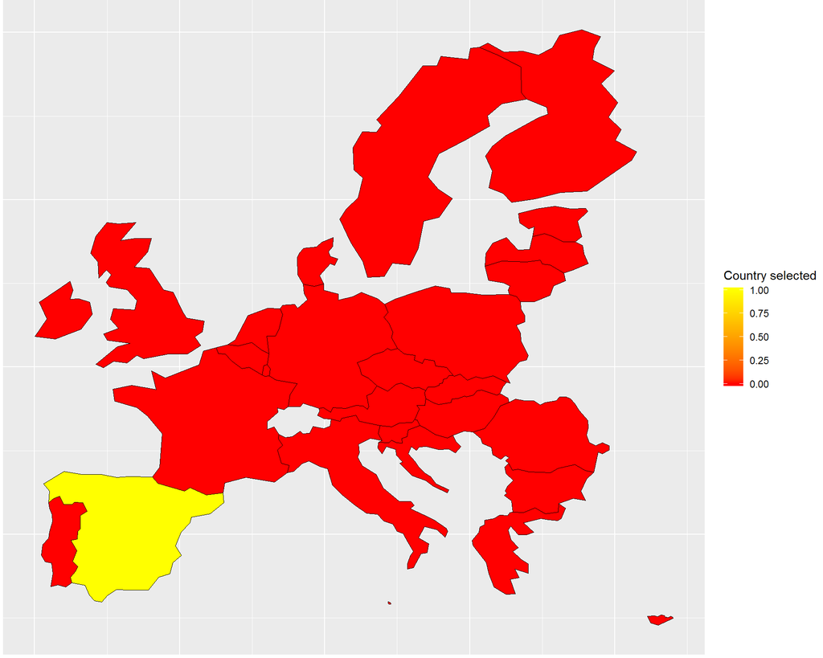